# Psychometric modeling of the Syntactic Complexity Scale of the CDI

Seamus Donnelly

```r
library(wordbankr) # WB data
library(tidyverse) # tidy
library(mirt) # IRT models
library(ltm) # more IRT functions
#library(difr) # some differential item functioning tools.
library(psych) # some psychometric stuff (tests of dimensionality)
library(Gifi)# some more psychometric stuff (tests of dimensionality)
library(knitr) # some formatting, tables, etc
library(patchwork) # combining plots.
library(GGally) # More plottinng options.
library()
```

# 1 A quick intro to IRT

Item response theory is a class of models for estimating the difficulty of items and the proficiency level of participants. Imagine we have a data set with *i* binary items and *v* participants. If we wanted to predict how well Person 1 did on Item 1, we could just take the difference between Person 1’s latent ability, and the difficulty of Item 1:

For intuition, if a person’s ability equals the item’s difficulty parameter, the difference is 0, and the equation above produces a probability of .5. When $\theta$ is larger than $\beta$, the probabilility will be greater than .5, and when $\theta$ is smaller than $\beta$ the probability will be smaller than .5. (Most programs swap the sign on $\beta$ for interpretability).

The Rasch makes a strict assumption–that items vary in their difficulty, but not in how well they discriminate between participants of varying ability levels. This is easier to wrap your head around with an example. I’ve fit a Rasch model to some data, and plotted item characteristic curves for some items. These tell us how estimated ability relates to the the probability of a correct response.

```r
library(MPsychoR)
```

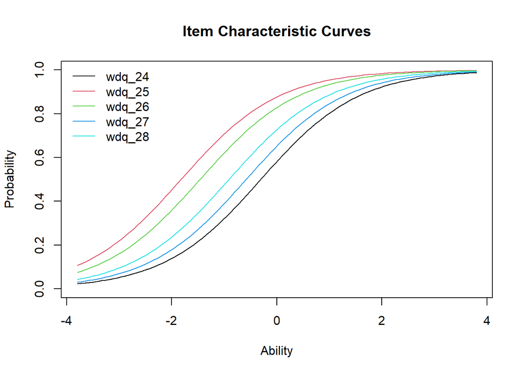

```r
data("RWDQ")
rasch <- rasch(RWDQ[,-1] )
plot(rasch, item=2:6, legend=TRUE)
```

The thing to notice here is that these are all parallel. The items vary in the latent ability necessary to get a item correct 50% of the time (an intercept basically) but not in how well they discriminate between participants of different ability levels. We can modify the Rasch model above by adding a discrimination parameter $\alpha$. this gives us the 2 parameter logistic regression equation below, which is what I use in the subsequent analyses:

$$\left(X_{v i}=1\right)=\frac{\exp \left(\alpha_{i}\left(\theta_{v}-\beta_{i}\right)\right)}{1+\exp \left(\alpha_{i}\left(\theta_{v}-\beta_{i}\right)\right)}$$
Adding $\alpha$ allows the item response curves to have different slopes.

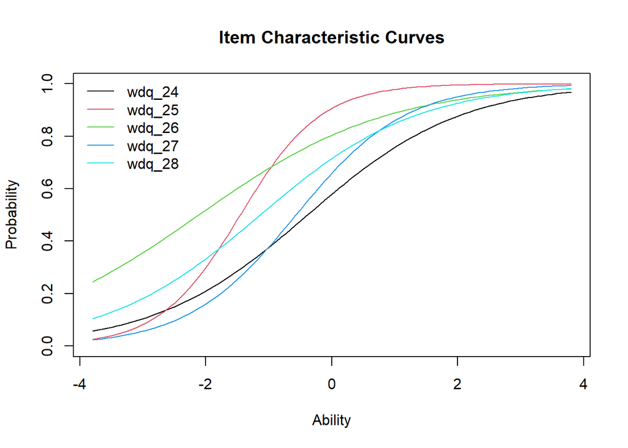

```r
l2p <- ltm(RWDQ[,-1] ~z1)
plot(l2p, item=2:6, legend=TRUE)
```

Now the item functions can cross. This means that some items don’t discriminate as well as well as others. So wdq_25 is largely affected by changes in ability from -2 t 0, but levels off after 0, whereas wdq_24 is affected by changes in ability across the whole range.

So to sum this introduction up, the 2 parameter model allows us to estimate abilities which are characteristics of participants, and difficulty and discrimination parameters, which are properties of items.

# 2 Preliminaries and Data Screening

Ok now on to the Word Bank data.

Download data from Word Bank:

```r
Inst <- get_instrument_data(language="English (American)", form="WS")
Admin <- get_administration_data(language="English (American)", form="WS")
Item <- get_item_data(language="English (American)", form = "WS")
```

Combine data sets. Create binary variable for accuracy.

```r
Complex <- Admin %>%
  full_join(.,Inst, by="data_id") %>%
  full_join(., Item, by="num_item_id") %>%
  filter(longitudinal==FALSE) %>%
  filter(type == "complexity") %>%
  mutate(
    out = ifelse(value=="complex", yes=1, no=0)
  )
```

## 2.1 Data Screening

Let’s see how many missing values there are.

```r
Complex %>%
  filter(is.na(out)) %>%
  group_by(definition) %>%
  count() # looks like 1426 participants don't have item-level complexity scores.
```

| definition | n |
| --- | --- |
| baby blanket / baby's blanket | 1426 |
| baby crying / baby crying cuz she's sad | 1426 |
| baby crying / baby is crying | 1426 |
| baby want eat / baby want to eat | 1426 |
| coffee hot / that coffee hot | 1426 |
| cookie mommy / cookie for mommy | 1426 |
| daddy car / daddy's car | 1426 |
| daddy pick me up / daddy picked me up | 1426 |
| doggie kiss me / doggie kissed me | 1426 |
| doggie table / doggie on table | 1426 |

[output cut: 27 more lines]

Looks like there are 1426 participants don’t have item-level complexity scores. So let’s drop those.

```r
Complex <- filter(Complex, !is.na(out))
```

Let’s look at means and SDs for each item:

```r
Complex %>%
  group_by(definition) %>%
  summarise(
    mean=mean(out),
    sd=sd(out),
    category = first(complexity_category)
  ) %>%
  arrange(category) %>%
  kable(caption="Means and SDs for Each Item (Arranged by Item)")
```

Means and SDs for Each Item (Arranged by Item)

| definition | mean | sd | category |
| --- | --- | --- | --- |
| baby blanket / baby’s blanket | 0.3873745 | 0.4872378 | morphology |
| daddy car / daddy’s car | 0.4451220 | 0.4970684 | morphology |
| daddy pick me up / daddy picked me up | 0.1743185 | 0.3794512 | morphology |
| doggie kiss me / doggie kissed me | 0.1879484 | 0.3907410 | morphology |
| I fall down / I fell down | 0.1807747 | 0.3849005 | morphology |
| I make tower / I making tower | 0.2360115 | 0.4247055 | morphology |
| kitty go away / kitty went away | 0.1280488 | 0.3342041 | morphology |
| kitty sleep / kitty sleeping | 0.4192970 | 0.4935326 | morphology |
| more cookie / more cookies | 0.3758967 | 0.4844404 | morphology |
| these my tooth / these my teeth | 0.4533716 | 0.4979103 | morphology |
| two foot / two feet | 0.4214491 | 0.4938798 | morphology |
| two shoe / two shoes | 0.4422525 | 0.4967431 | morphology |
| baby crying / baby crying cuz she’s sad | 0.1599713 | 0.3666452 | syntax |
| baby crying / baby is crying | 0.1624821 | 0.3689586 | syntax |
| baby want eat / baby want to eat | 0.2650646 | 0.4414468 | syntax |
| coffee hot / that coffee hot | 0.1929699 | 0.3947004 | syntax |
| cookie mommy / cookie for mommy | 0.2413917 | 0.4280040 | syntax |
| doggie table / doggie on table | 0.3511478 | 0.4774147 | syntax |
| don’t read book / don’t want you read that book | 0.1818508 | 0.3857907 | syntax |
| go bye-bye / wanna go bye-bye | 0.2679340 | 0.4429625 | syntax |
| I like read stories / I like to read stories | 0.1779053 | 0.3825016 | syntax |
| I no do it / I can’t do it | 0.2482066 | 0.4320498 | syntax |
| I sing song / I sing song for you | 0.1449067 | 0.3520699 | syntax |
| I want that / I want that one you got | 0.1137016 | 0.3175054 | syntax |
| lookit / lookit what I got | 0.2410330 | 0.4277870 | syntax |
| lookit me / lookit me dancing | 0.2596844 | 0.4385400 | syntax |
| no wash dolly / don’t wash dolly | 0.2116212 | 0.4085310 | syntax |
| read me story Mommy / read me a story Mommy | 0.1635581 | 0.3699405 | syntax |
| that my truck / that’s my truck | 0.2822812 | 0.4501902 | syntax |
| there a kitty / there’s a kitty | 0.3210187 | 0.4669517 | syntax |
| turn on light / turn on light so I can see | 0.0961263 | 0.2948172 | syntax |
| want cookies / want cookies and milk | 0.2048063 | 0.4036324 | syntax |
| want more juice / want juice in there | 0.2051650 | 0.4038946 | syntax |
| we made this / me and Paul made this | 0.1603300 | 0.3669776 | syntax |
| where’s my dolly / where’s my dolly name Sam | 0.1093974 | 0.3121932 | syntax |
| where mommy go / where did mommy go | 0.1822095 | 0.3860863 | syntax |
| you fix it / can you fix it | 0.1025825 | 0.3034672 | syntax |

Let’s also check the distribution of means for each category

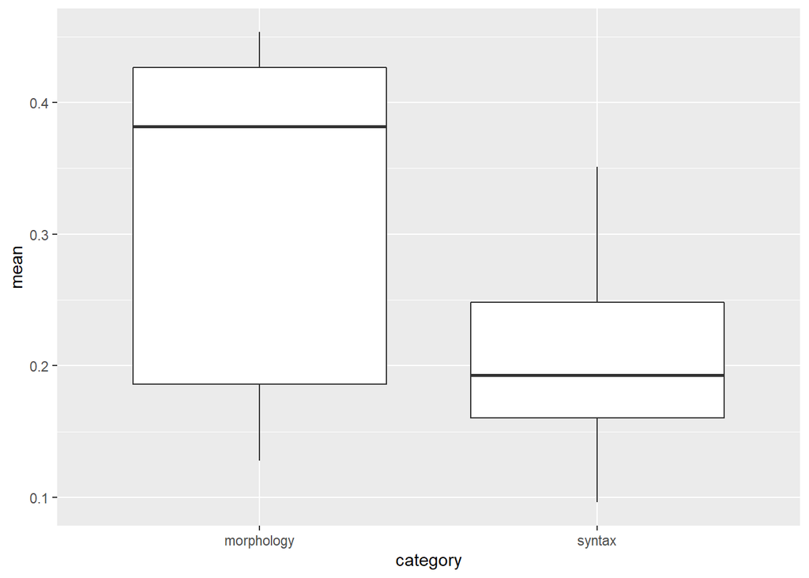

```r
Complex %>%
  group_by(definition) %>%
  summarise(
    mean=mean(out),
    category = first(complexity_category)
  ) %>%
  ggplot(aes(x=category, y= mean)) + geom_boxplot()
```

## 2.2 Data Preparation

Prepare data set for IRT modeling. I’m going to re-name each item to its category (morphology or syntax) and its item number so as to make some graphs easier to read.

```r
Complex_short_with_ids <- Complex %>% # made
  dplyr::select(data_id, value, complexity_category, num_item_id) %>%
  mutate(
    out = ifelse(value=="complex", yes=1, no=0),
    label = str_c(complexity_category, num_item_id)
  ) %>%
  dplyr::select(-value) %>%
  pivot_wider(id_cols=data_id, names_from = "label", values_from="out") # dataset for IRT can't have IDs

Complex_short <- Complex_short_with_ids %>%
  dplyr::select(-data_id)
```

## 2.3 Dimensionality Assessment

Prior to fitting the IRT model, it’s worth looking at the correlation structure of the data to get a sense of the possible dimensionality.

Create tetrachoric correlation matrix (for binary data). I created a vector with labels, for labeling of the correlation plot.

```r
Complex_poly <- tetrachoric(Complex_short)
```

```r
rho <- Complex_poly$rho

lab = c("1", "2", "3", "4", "5", "6", "7", "8", "9", "10", "11", "12", "13", "14", "15", "16", "17", "18", "19", "20", "21", "22", "23", "24", "25", "26", "27", "28", "29", "30", "31", "32", "33", "34", "35", "36", "37") # create labels for corPlot because the defintions are long and take up a ton of space
```

Check out the correlations

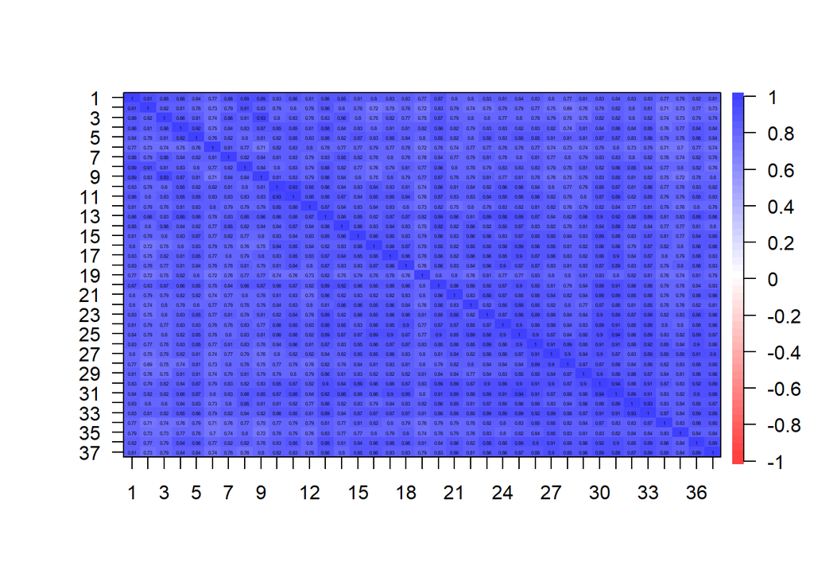

```r
corPlot(rho, labels=lab)
```

They look really high. Let’s examine the dimensionality, using princals, which is basically just a version of PCA that is appropriate for categorical data.

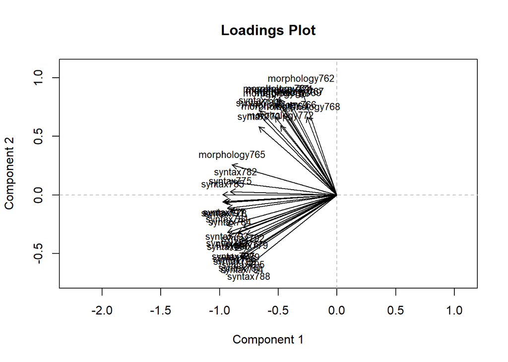

```r
pc <- princals(rho)

plot(pc)
```

Interesting. Seems like maybe there are 2 factors. An alternative approach is a scree plot with confidence intervals from simulated data:

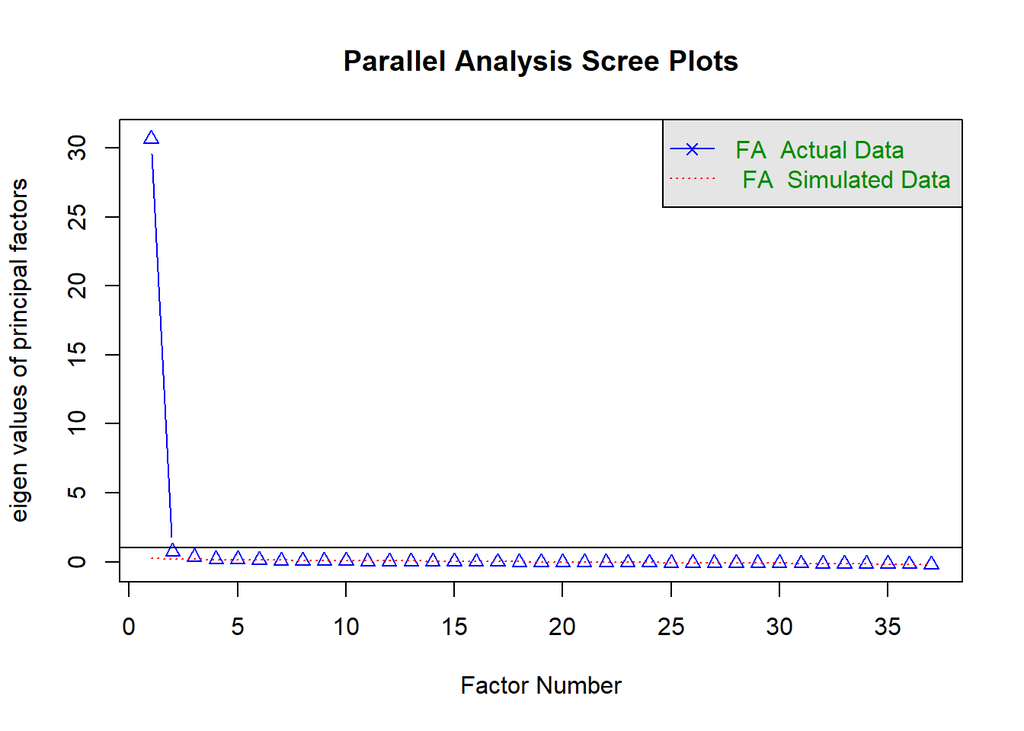

```
## Parallel analysis suggests that the number of factors =  5  and the number of components =  NA
```

```r
fa.parallel(rho, fa="fa", cor="tet", n.obs = 2788)
```

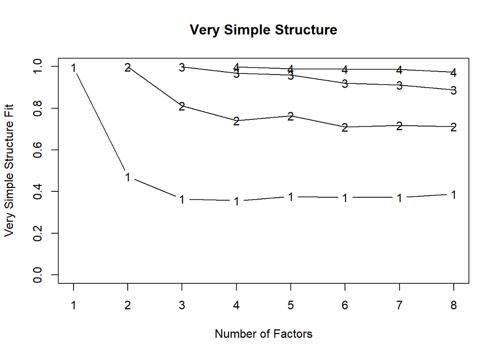

```
##
## Very Simple Structure
## Call: vss(x = rho, n.obs = 2788, cor = "tet")
## VSS complexity 1 achieves a maximimum of 1  with  1  factors
## VSS complexity 2 achieves a maximimum of 1  with  2  factors
##
## The Velicer MAP achieves a minimum of 0.02  with  4  factors
## BIC achieves a minimum of  17127.14  with  8  factors
## Sample Size adjusted BIC achieves a minimum of  18391.72  with  8  factors
##
## Statistics by number of factors
##   vss1 vss2   map dof chisq prob sqresid fit RMSEA   BIC SABIC complex eChisq
## 1 1.00 0.00 0.026 629 41190    0    2.18   1  0.15 36200 38199     1.0   2778
## 2 0.47 1.00 0.018 593 33101    0    1.37   1  0.14 28397 30281     1.8   1248
## 3 0.37 0.81 0.017 558 29519    0    1.08   1  0.14 25092 26865     2.5    826
## 4 0.36 0.74 0.017 524 26605    0    0.93   1  0.13 22448 24113     2.9    630
## 5 0.38 0.76 0.017 491 24433    0    0.81   1  0.13 20538 22098     3.1    489
## 6 0.37 0.71 0.018 459 22595    0    0.72   1  0.13 18954 20412     3.3    393
## 7 0.37 0.72 0.019 428 21444    0    0.64   1  0.13 18048 19408     3.3    331
## 8 0.39 0.71 0.020 398 20285    0    0.57   1  0.13 17127 18392     3.4    282
##     SRMR eCRMS  eBIC
## 1 0.0274 0.028 -2212
## 2 0.0183 0.019 -3457
## 3 0.0149 0.016 -3600
## 4 0.0130 0.015 -3527
## 5 0.0115 0.013 -3407
## 6 0.0103 0.012 -3248
## 7 0.0094 0.012 -3064
## 8 0.0087 0.011 -2875
```

```r
vss(rho, cor="tet", n.obs = 2788)
```

These tests seem to suggest a single factor is probably the best approach, though it’s possible a two factor approach would be better.

# 3 IRT Modeling

## 3.1 2PL model

Let’s first fit the 2pl model and examine the output.

```r
m1 <- mirt(Complex_short, 1, itemtype="2PL", verbose=FALSE)
```

```r
m1
```

```
##
## Call:
## mirt(data = Complex_short, model = 1, itemtype = "2PL", verbose = FALSE)
##
## Full-information item factor analysis with 1 factor(s).
## Converged within 1e-04 tolerance after 197 EM iterations.
## mirt version: 1.33.2
## M-step optimizer: BFGS
## EM acceleration: Ramsay
## Number of rectangular quadrature: 61
## Latent density type: Gaussian
##
## Log-likelihood = -25839.34
## Estimated parameters: 74
## AIC = 51826.68; AICc = 51830.77
## BIC = 52265.72; SABIC = 52030.6
## G2 (1e+10) = 24307.36, p = 1
## RMSEA = 0, CFI = NaN, TLI = NaN
```

```r
summary(m1)
```

```
##                  F1    h2
## morphology761 0.930 0.866
## morphology762 0.899 0.808
## morphology763 0.904 0.818
## morphology764 0.923 0.852
## morphology765 0.937 0.879
## morphology766 0.881 0.776
## morphology767 0.904 0.817
## morphology768 0.917 0.840
## morphology769 0.915 0.838
## morphology770 0.937 0.878
## morphology771 0.952 0.906
## morphology772 0.927 0.859
## syntax773     0.958 0.918
## syntax774     0.938 0.879
## syntax775     0.948 0.899
## syntax776     0.952 0.907
## syntax777     0.953 0.908
## syntax778     0.942 0.887
## syntax779     0.897 0.805
## syntax780     0.953 0.908
## syntax781     0.933 0.870
## syntax782     0.934 0.872
## syntax783     0.956 0.913
## syntax784     0.949 0.901
## syntax785     0.969 0.938
## syntax786     0.967 0.934
## syntax787     0.960 0.922
## syntax788     0.940 0.884
## syntax789     0.937 0.878
## syntax790     0.969 0.939
## syntax791     0.973 0.947
## syntax792     0.947 0.896
## syntax793     0.966 0.934
## syntax794     0.928 0.862
## syntax795     0.912 0.832
## syntax796     0.967 0.934
## syntax797     0.953 0.908
##
## SS loadings:  32.613
## Proportion Var:  0.881
##
## Factor correlations:
##
##    F1
## F1  1
```

Let’s check the overall fit of the model. The chi square statistic here isn’t super meaningful given the sample size.

```r
M2(m1)
```

|  | M2 | df | p | RMSEA | RMSEA_5 | RMSEA_95 | SRMSR | TLI | CFI |
| --- | --- | --- | --- | --- | --- | --- | --- | --- | --- |
| stats | 3294.486 | 629 | 0 | 0.0389937 | 0.03767887 | 0.04030537 | 0.06022364 | 0.995046 | 0.9953212 |

RMSEA and CFI are good, SRMSR is a bit high but pretty reasonable. We can see if individual items misfit – i.e., do the observed cell counts differ from the expected cell counts.

```r
itemfit(m1)
```

| item | S_X2 | df.S_X2 | RMSEA.S_X2 | p.S_X2 |
| --- | --- | --- | --- | --- |
| morphology761 | 29.58418 | 24 | 0.009137042 | 0.19891772 |
| morphology762 | 45.12596 | 28 | 0.014814259 | 0.02142273 |
| morphology763 | 35.49900 | 27 | 0.010627561 | 0.12667057 |
| morphology764 | 38.92504 | 26 | 0.013355521 | 0.04956424 |
| morphology765 | 27.93105 | 32 | 0.000000000 | 0.67276598 |
| morphology766 | 33.63907 | 34 | 0.000000000 | 0.48520166 |
| morphology767 | 28.22048 | 30 | 0.000000000 | 0.55875415 |
| morphology768 | 31.84702 | 25 | 0.009913162 | 0.16248644 |
| morphology769 | 38.36442 | 28 | 0.011524578 | 0.09170029 |
| morphology770 | 34.39371 | 32 | 0.005180741 | 0.35382552 |

[output cut: 27 more lines]

A few items significantly misfit. Let’s take everything with a p value less than .10. We’ll look at item gam plots of those, which plot the item response probability against the latent variable using a gam function, to look for deviations in the item-response function.

```r
misfit <- itemfit(m1) %>% # Get labels of mis-fitting items.
  filter(p.S_X2 <= .10) %>%
  dplyr::select(item) %>%
  as.vector()

items_good <- dplyr::select(Complex_short, -all_of(misfit$item)) # Well fitting items
items_bad <- dplyr::select(Complex_short, all_of(misfit$item)) # Poorly fitting items

mod_fit <- mirt(items_good, 1, "2PL", verbose=FALSE) # Calculate factor scores using only the well fitting items.
Theta <- fscores(mod_fit)

# Plot non-linear item response theory curves with the factor scores
IG762 <- itemGAM(items_bad$morphology762,Theta)
IG764 <- itemGAM(items_bad$morphology764,Theta)
IG769<- itemGAM(items_bad$morphology769,Theta)
IG771 <- itemGAM(items_bad$morphology771,Theta)

IG783 <- itemGAM(items_bad$syntax783,Theta)
IG792 <- itemGAM(items_bad$syntax792,Theta)
```

Here are the morphology items

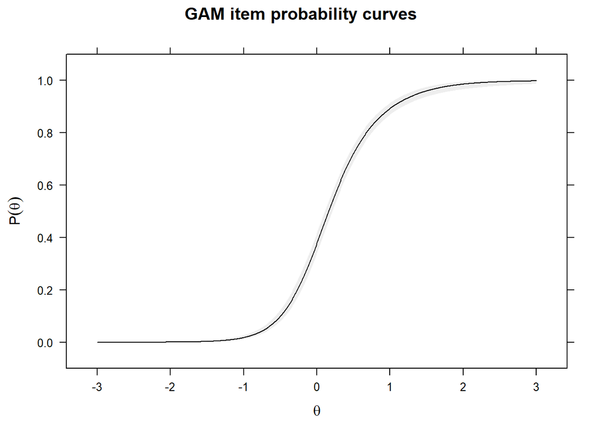

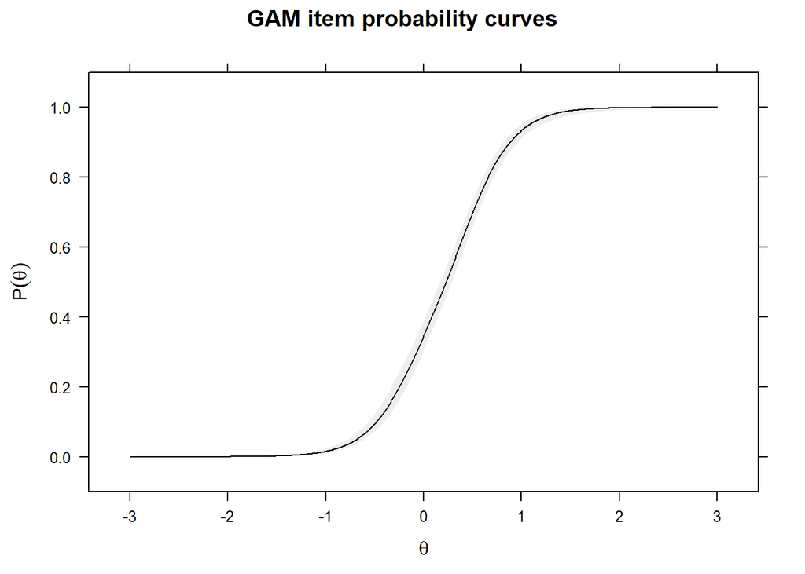

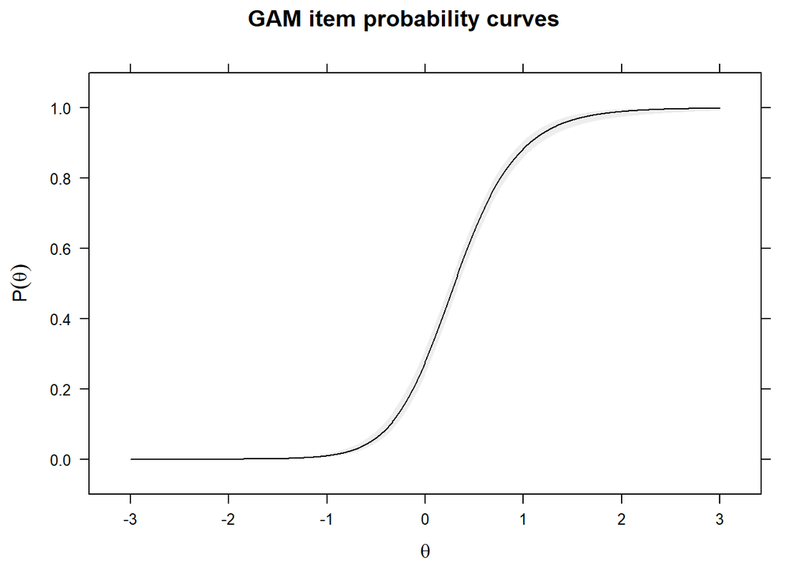

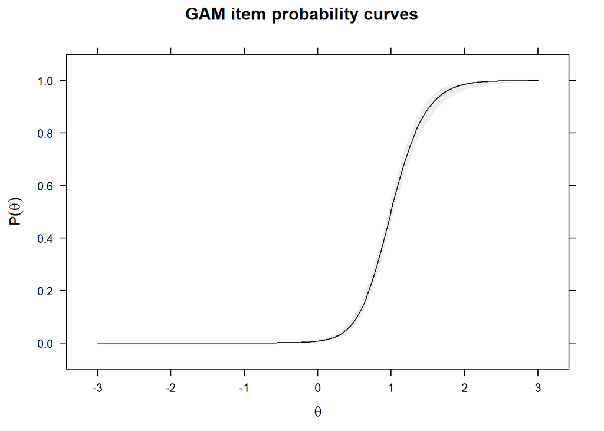

```r
plot(IG762); plot(IG764); plot(IG769); plot(IG771)
```

```r
par(par(mfrow=c(2,2)))
```

Syntax items

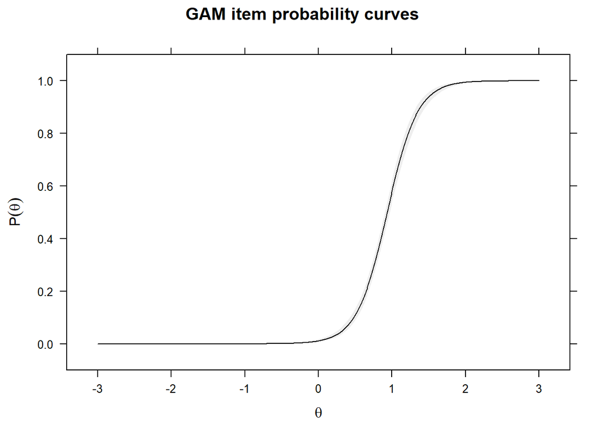

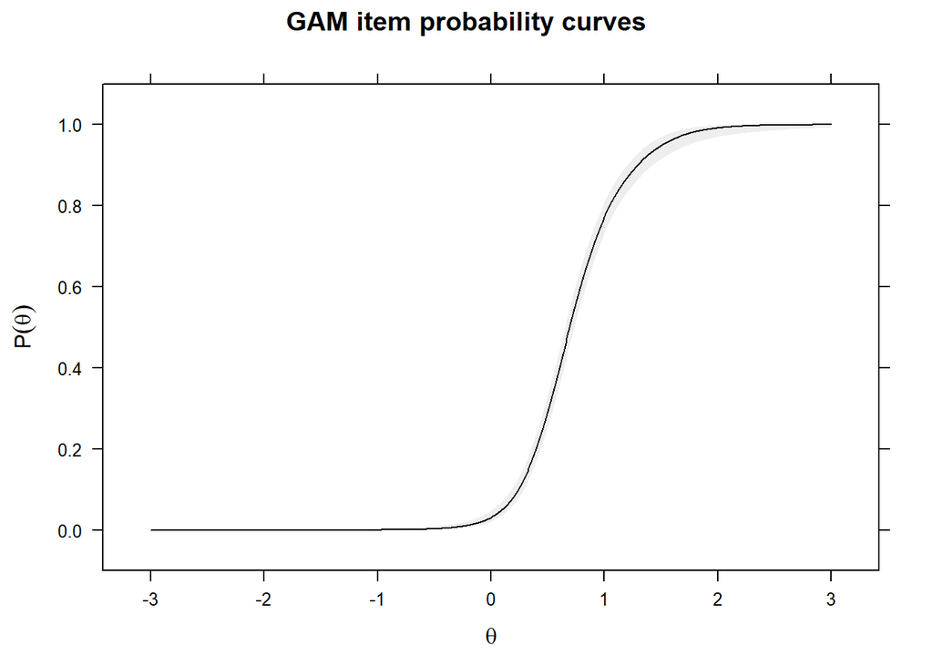

```r
plot(IG783); plot(IG792)
```

These don’t look like massive deviations. They are all monotonic, certainly, but they seem to slow down more than the logistic function.

Next let’s look at the relationship between the true scores and the raw scores.

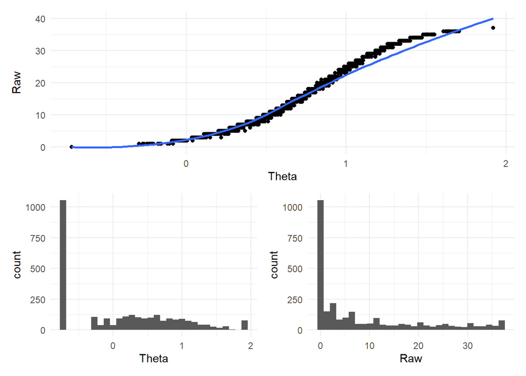

```r
true_raw <- Complex_short %>%
  mutate(
    Raw = rowSums(.[,1:37]),
    Theta = fscores(m1, method="MAP")
  ) %>%
  ggplot(aes(x=Theta, y=Raw)) + geom_point() + stat_smooth(method="loess") + theme_minimal()

raw_score <- Complex_short %>%
  mutate(
    Raw = rowSums(.[,1:37])
    ) %>%
   ggplot(aes(x=Raw)) + geom_histogram() + theme_minimal()

true_score <- Complex_short %>%
  mutate(
    Theta = fscores(m1, method="MAP")
    ) %>%
   ggplot(aes(x=Theta)) + geom_histogram() + theme_minimal()

library(patchwork)

true_raw/(true_score + raw_score)
```

Two things suggest this is a more precise measurement: the relationship between the true and raw scores is sigmoid-ish, and there are multiple values of the true score at every level of the observed score. Also, note the number of 0s on the raw score, and really high scores on the true score.

Next let’s take a look at the difficulty and discrimination parameter for each item.

```r
coefs_2pl <- coef(m1, as.data.frame = TRUE) %>%
 t() %>%
  as_tibble() %>%
  dplyr::select(-c(149:150)) %>%
  pivot_longer(everything()) %>%
  separate(, col=name, into=c("item", "parameter"), sep="([.])") %>%
  pivot_wider(id_cols=item, names_from=parameter, values_from=value) %>%
  dplyr::select(item, a1, d) %>%
  mutate(
   category =  gsub('[[:digit:]]+', '', item)
  )
```

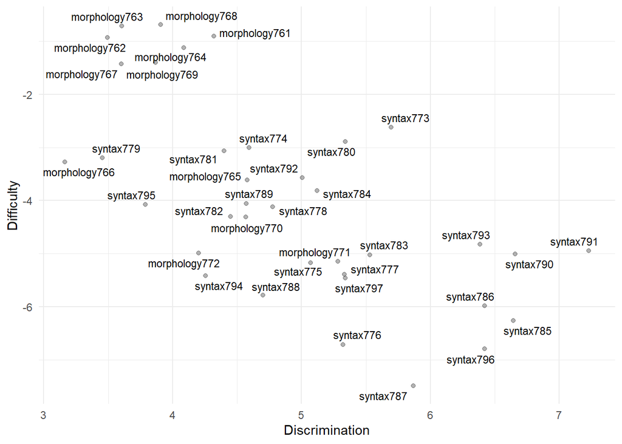

```r
ggplot(coefs_2pl,
       aes(x = a1, y = d)) +
  geom_point(alpha = .3) +
  ggrepel::geom_text_repel(data = coefs_2pl,
                  aes(label = item), size = 3) +
  xlab("Discrimination") +
  ylab("Difficulty") + theme_minimal()
```

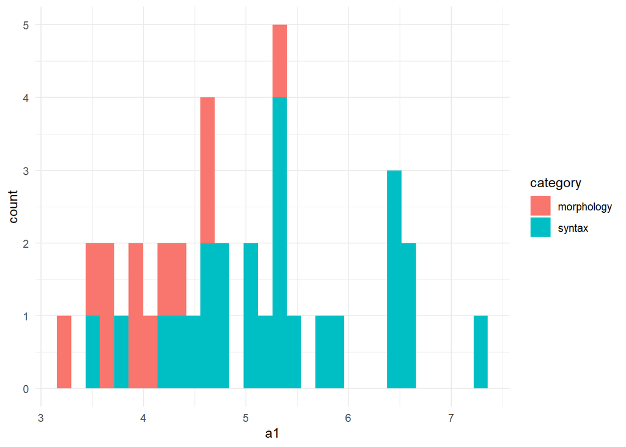

```r
ggplot(coefs_2pl, aes(x=a1, fill=category)) + geom_histogram() + theme_minimal()
```

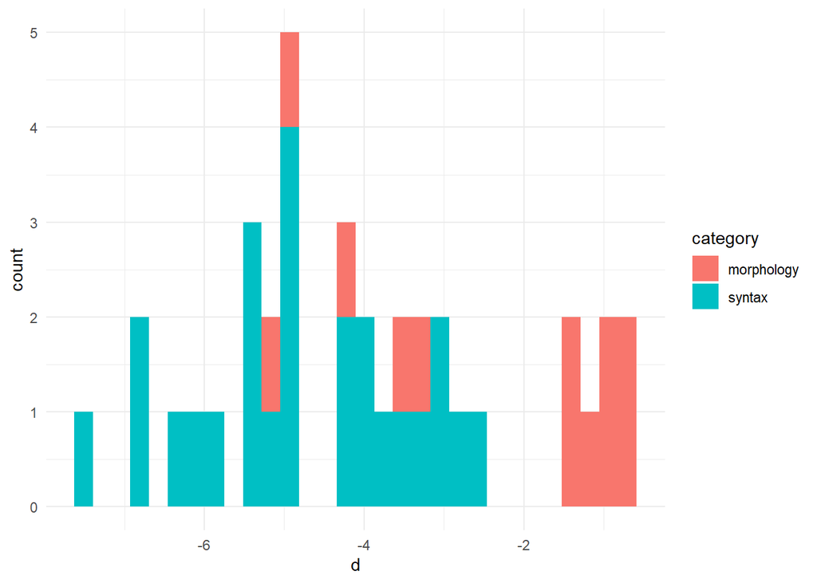

```r
ggplot(coefs_2pl, aes(x=d, fill=category)) + geom_histogram() + theme_minimal()
```

Strong correlation between the difficulty and discrimination parameter. Also note that the morphology items are less difficult than the syntax ones in general.

## 3.2 Thinking Through the Assumptions of the 2PL model

It’s important to remember that these latent variables are only interpretable if the following conditions hold: 1. The assumption of unidimensionality is appropriate. 2. The assumed distributional form of the latent variable is correct. 3. Measurement invariance holds: the items behave the same way across different groups of participants.

I can test 1 and 2 on my own. 3 is a bit of a stretch for me right now.

### 3.2.1 Non-parametric model relaxing assumption of normal latent variable.

Let’s look at the distribution of the latent variable first. MIRT allows us to relax the assumption of normally distributed latent variables at the cost of loss of flexibility. I’ll look at a model which makes no assumptions about the form of the latent variable **note to self: check this later** , and compare results to those above.

```r
m1_nonpar <- mirt(Complex_short, 1, itemtype="2PL", dentype = "EH", verbose=FALSE)

M2(m1_nonpar)
```

|  | M2 | df | p | RMSEA | RMSEA_5 | RMSEA_95 | SRMSR | TLI | CFI |
| --- | --- | --- | --- | --- | --- | --- | --- | --- | --- |
| stats | 3619.1 | 629 | 0 | 0.04129991 | 0.0399921 | 0.04260353 | 0.218018 | 0.9944427 | 0.9947514 |

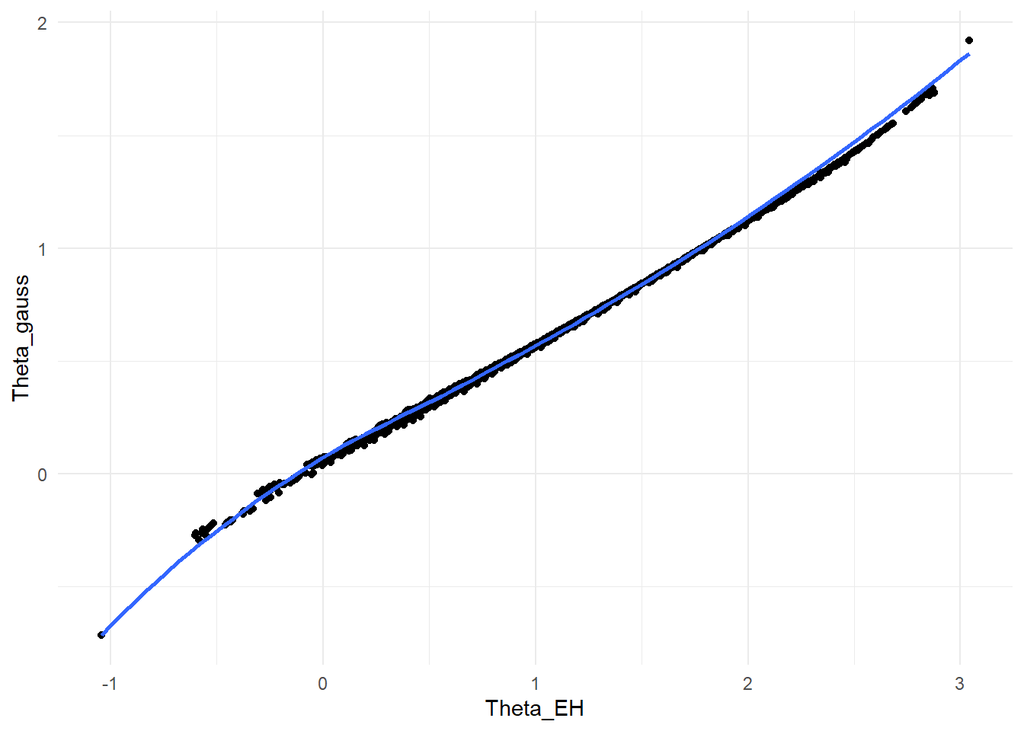

```r
Complex_short %>%
  mutate(
    Theta_EH = fscores(m1_nonpar, method="MAP"),
    Theta_gauss = fscores(m1, method="MAP")
  ) %>%
  ggplot(aes(x=Theta_EH, y=Theta_gauss)) + geom_point() + stat_smooth(method="loess") + theme_minimal()
```

These are quite similar though a bit different in the tails. There’s another type of non-parametric latent variable in MIRT.

```r
m1_nonpar2 <- mirt(Complex_short, 1, itemtype="2PL", dentype = "EHW", verbose=FALSE)

M2(m1_nonpar2)
```

|  | M2 | df | p | RMSEA | RMSEA_5 | RMSEA_95 | SRMSR | TLI | CFI |
| --- | --- | --- | --- | --- | --- | --- | --- | --- | --- |
| stats | 4888.329 | 629 | 0 | 0.04929204 | 0.04800098 | 0.05057514 | 0.1792494 | 0.9920837 | 0.9925235 |

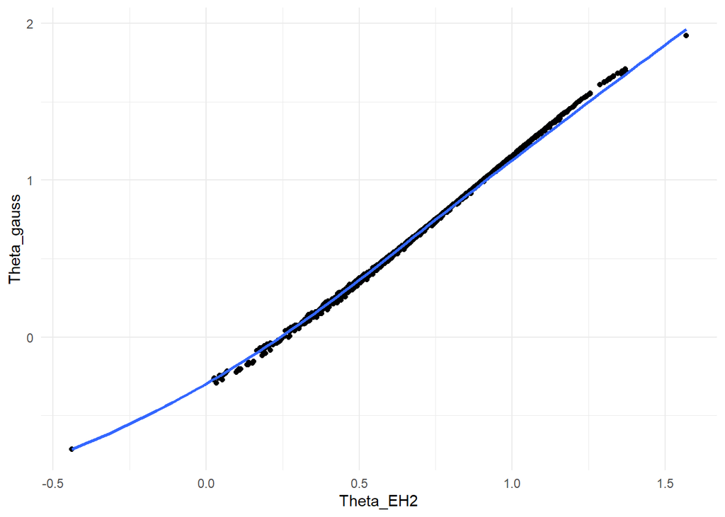

```r
Complex_short %>%
  mutate(
    Theta_EH2 = fscores(m1_nonpar2, method="MAP"),
    Theta_gauss = fscores(m1, method="MAP")
  ) %>%
  ggplot(aes(x=Theta_EH2, y=Theta_gauss)) + geom_point() + stat_smooth(method="loess") + theme_minimal()
```

These are also very, very close. I think it’s sensible to stick with the Gaussian model. It fits better, its simpler and more flexible, and the factor scores are really, really similar across the two approaches.

The next thing we can do is check the dimensionality. I got mixed results before. Check dimensionality against 2 dimensional model.

### 3.2.2 Test assumption of unidimensionality

First a formal test of dimensionality. We need to fit the model with ltm. The unidimTest takes forever to run and produces enormous output, so it’s commented out.

```r
#m1_ltm <- ltm(Complex_short ~z1)
#unidimTest(m1_ltm, Complex_short)
```

Exploratory 2 dimensional IRT.

```r
m2 <- mirt(Complex_short, 2, itemtype="2PL", verbose=FALSE)
```

```r
M2(m2)
```

|  | M2 | df | p | RMSEA | RMSEA_5 | RMSEA_95 | SRMSR | TLI | CFI |
| --- | --- | --- | --- | --- | --- | --- | --- | --- | --- |
| stats | 1962.909 | 593 | 0 | 0.02879056 | 0.02737998 | 0.03020164 | 0.03637544 | 0.9972994 | 0.9975954 |

```r
anova(m1, m2)
```

```
##
## Model 1: mirt(data = Complex_short, model = 1, itemtype = "2PL", verbose = FALSE)
## Model 2: mirt(data = Complex_short, model = 2, itemtype = "2PL", verbose = FALSE)
```

| AIC | AICc | SABIC | HQ | BIC | logLik | X2 | df | p |
| --- | --- | --- | --- | --- | --- | --- | --- | --- |
| 51826.68 | 51830.77 | 52030.60 | 51985.19 | 52265.72 | -25839.34 | NaN | NaN | NaN |
| 51021.43 | 51030.56 | 51324.57 | 51257.06 | 51674.07 | -25400.72 | 877.2438 | 36 | 0 |

```r
summary(m2, "oblimin", suppress=.20)
```

```
##
## Rotation:  oblimin
##
## Rotated factor loadings:
##
##                   F1     F2    h2
## morphology761 -0.898 -0.229 0.892
## morphology762 -0.873     NA 0.820
## morphology763 -0.856 -0.334 0.890
## morphology764 -0.902     NA 0.855
## morphology765 -0.925     NA 0.869
## morphology766 -0.863     NA 0.774
## morphology767 -0.878     NA 0.827
## morphology768 -0.901     NA 0.839
## morphology769 -0.876 -0.292 0.894
## morphology770 -0.922     NA 0.887
## morphology771 -0.937     NA 0.921
## morphology772 -0.911     NA 0.869
## syntax773     -0.950     NA 0.911
## syntax774     -0.920     NA 0.888
## syntax775     -0.940     NA 0.886
## syntax776     -0.948     NA 0.896
## syntax777     -0.946     NA 0.896
## syntax778     -0.937     NA 0.874
## syntax779     -0.890     NA 0.787
## syntax780     -0.938     NA 0.911
## syntax781     -0.932     NA 0.864
## syntax782     -0.924     NA 0.860
## syntax783     -0.955     NA 0.905
## syntax784     -0.947     NA 0.892
## syntax785     -0.966     NA 0.929
## syntax786     -0.968     NA 0.933
## syntax787     -0.964     NA 0.936
## syntax788     -0.943  0.217 0.902
## syntax789     -0.936     NA 0.873
## syntax790     -0.971     NA 0.937
## syntax791     -0.973     NA 0.942
## syntax792     -0.947     NA 0.891
## syntax793     -0.968     NA 0.931
## syntax794     -0.927     NA 0.856
## syntax795     -0.910     NA 0.830
## syntax796     -0.967     NA 0.932
## syntax797     -0.946  0.216 0.907
##
## Rotated SS loadings:  31.937 0.727
##
## Factor correlations:
##
##       F1    F2
## F1 1.000 0.082
## F2 0.082 1.000
```

This model fits better, but it doesn’t look like the second factor is adding much of anything. Also it looks like the correlation between factors is really small, which seems unlikely given the way language works.

Plot the discrimination parameters for each dimension against one another.

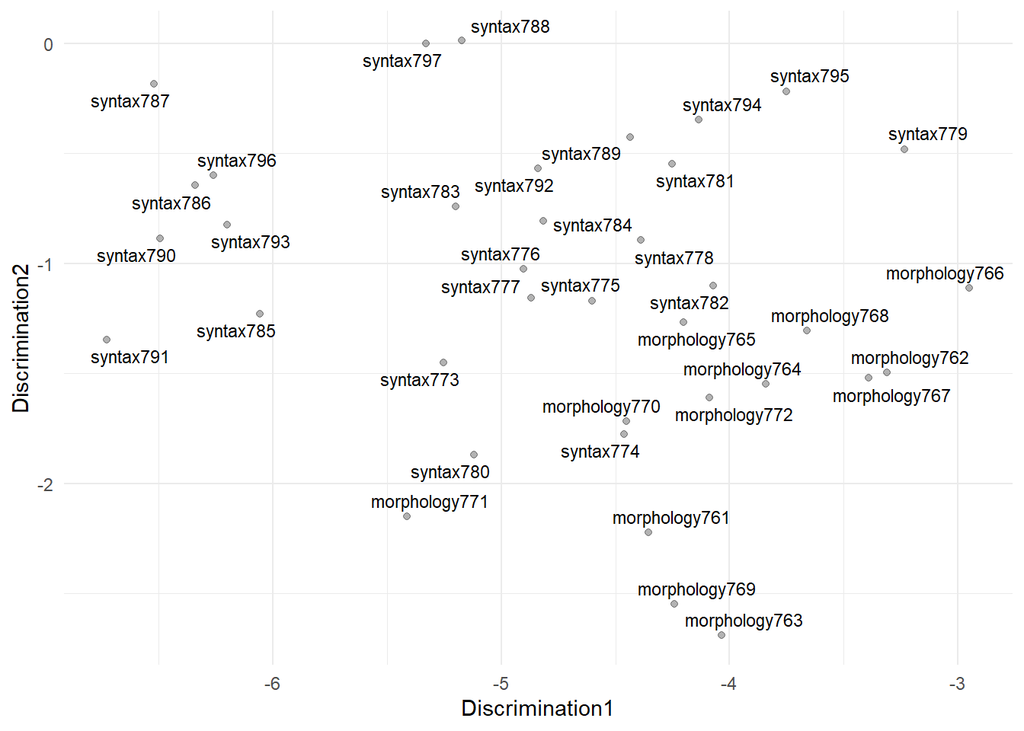

```r
coefs_2plmulti <- coef(m2, as.data.frame = TRUE) %>%
 t() %>%
  as_tibble() %>%
  dplyr::select(-c(185:190)) %>%
  pivot_longer(everything()) %>%
  separate(, col=name, into=c("item", "parameter"), sep="([.])") %>%
  pivot_wider(id_cols=item, names_from=parameter, values_from=value) %>%
  dplyr::select(item, a1, a2, d) %>%
  mutate(
   category =  gsub('[[:digit:]]+', '', item)
  )
ggplot(coefs_2plmulti ,
       aes(x = a1, y = a2)) +
  geom_point(alpha = .3) +
  ggrepel::geom_text_repel(data =coefs_2plmulti,
                  aes(label = item), size = 3) +
  xlab("Discrimination1") +
  ylab("Discrimination2") + theme_minimal()
```

2 discrimination parameters. They’re both negative. I’m wondering if these are parameterized a little bit differently, such that they mean something different in the two dimensional context.

Plot the latent variables against the raw scores and against one another.

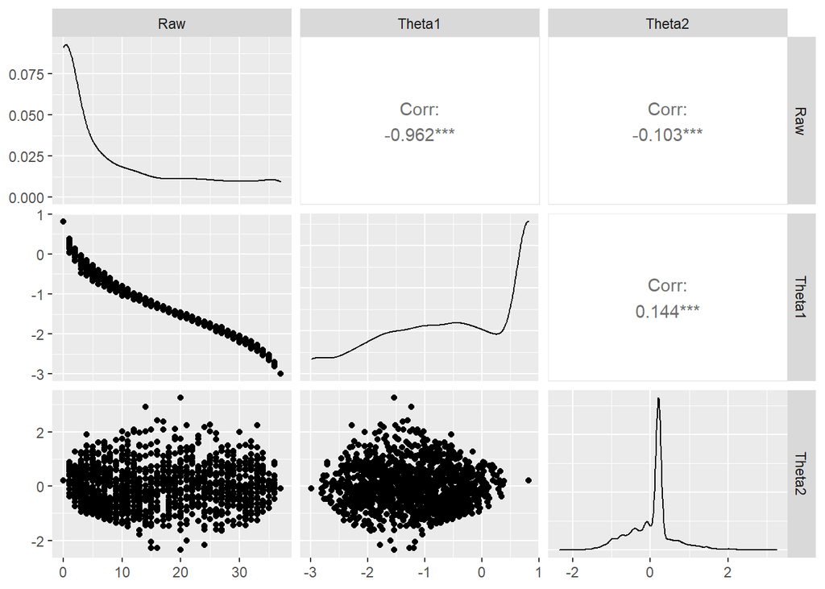

```r
Complex_short %>%
  mutate(
    Raw = rowSums(.[,1:37]),
    Theta1 = fscores(m2, method="MAP")[,1],
    Theta2 = fscores(m2, method="MAP")[,2]
  ) %>%
  dplyr::select(Raw, Theta1, Theta2) %>%
  ggpairs()
```

Another way to think about this problem is that perhaps the morphology and syntax items are measuring different proficiencies We can fit a confirmatory IRT model, with one morphology factor and on syntactic.

```r
model.1 <- mirt.model('
                      F1 = 1 - 12
                      F2 = 13 - 37
                      COV=F1*F2')

m3 <- mirt(Complex_short, model.1, "2PL", verbose=FALSE)

M2(m3)
```

|  | M2 | df | p | RMSEA | RMSEA_5 | RMSEA_95 | SRMSR | TLI | CFI |
| --- | --- | --- | --- | --- | --- | --- | --- | --- | --- |
| stats | 2587.97 | 629 | 0 | 0.03342875 | 0.03209024 | 0.03476626 | 0.033852 | 0.9963591 | 0.9965614 |

```r
summary(m3)
```

```
##                  F1    F2    h2
## morphology761 0.933 0.000 0.870
## morphology762 0.891 0.000 0.795
## morphology763 0.901 0.000 0.812
## morphology764 0.913 0.000 0.834
## morphology765 0.919 0.000 0.844
## morphology766 0.863 0.000 0.744
## morphology767 0.892 0.000 0.796
## morphology768 0.904 0.000 0.818
## morphology769 0.913 0.000 0.833
## morphology770 0.934 0.000 0.872
## morphology771 0.958 0.000 0.917
## morphology772 0.922 0.000 0.851
## syntax773     0.000 0.939 0.882
## syntax774     0.000 0.907 0.824
## syntax775     0.000 0.925 0.856
## syntax776     0.000 0.931 0.868
## syntax777     0.000 0.930 0.865
## syntax778     0.000 0.916 0.840
## syntax779     0.000 0.862 0.744
## syntax780     0.000 0.931 0.866
## syntax781     0.000 0.911 0.829
## syntax782     0.000 0.907 0.823
## syntax783     0.000 0.936 0.876
## syntax784     0.000 0.926 0.857
## syntax785     0.000 0.951 0.904
## syntax786     0.000 0.952 0.907
## syntax787     0.000 0.947 0.897
## syntax788     0.000 0.922 0.850
## syntax789     0.000 0.912 0.832
## syntax790     0.000 0.956 0.915
## syntax791     0.000 0.962 0.925
## syntax792     0.000 0.927 0.859
## syntax793     0.000 0.952 0.905
## syntax794     0.000 0.904 0.817
## syntax795     0.000 0.883 0.780
## syntax796     0.000 0.950 0.902
## syntax797     0.000 0.932 0.869
##
## SS loadings:  9.985 21.49
## Proportion Var:  0.27 0.581
##
## Factor correlations:
##
##       F1    F2
## F1 1.000 0.959
## F2 0.959 1.000
```

The fit is pretty good, but the correlation between the latent variables is very high, .959

Compare the fit to the one dimension model and two-dimension exploratory model.

```r
anova(m1, m3)
```

```
##
## Model 1: mirt(data = Complex_short, model = 1, itemtype = "2PL", verbose = FALSE)
## Model 2: mirt(data = Complex_short, model = model.1, itemtype = "2PL",
##     verbose = FALSE)
```

| AIC | AICc | SABIC | HQ | BIC | logLik | X2 | df | p |
| --- | --- | --- | --- | --- | --- | --- | --- | --- |
| 51826.68 | 51830.77 | 52030.60 | 51985.19 | 52265.72 | -25839.34 | NaN | NaN | NaN |
| 51525.16 | 51529.36 | 51731.84 | 51685.81 | 51970.14 | -25687.58 | 303.5217 | 1 | 0 |

```r
anova(m2, m3)
```

```
##
## Model 1: mirt(data = Complex_short, model = model.1, itemtype = "2PL",
##     verbose = FALSE)
## Model 2: mirt(data = Complex_short, model = 2, itemtype = "2PL", verbose = FALSE)
```

| AIC | AICc | SABIC | HQ | BIC | logLik | X2 | df | p |
| --- | --- | --- | --- | --- | --- | --- | --- | --- |
| 51525.16 | 51529.36 | 51731.84 | 51685.81 | 51970.14 | -25687.58 | NaN | NaN | NaN |
| 51021.43 | 51030.56 | 51324.57 | 51257.06 | 51674.07 | -25400.72 | 573.7221 | 35 | 0 |

It its better than the 1 dimension, but worse than the 2 dimension exploratory model. Let’s try plotting each of the proficiencies against the raw data.

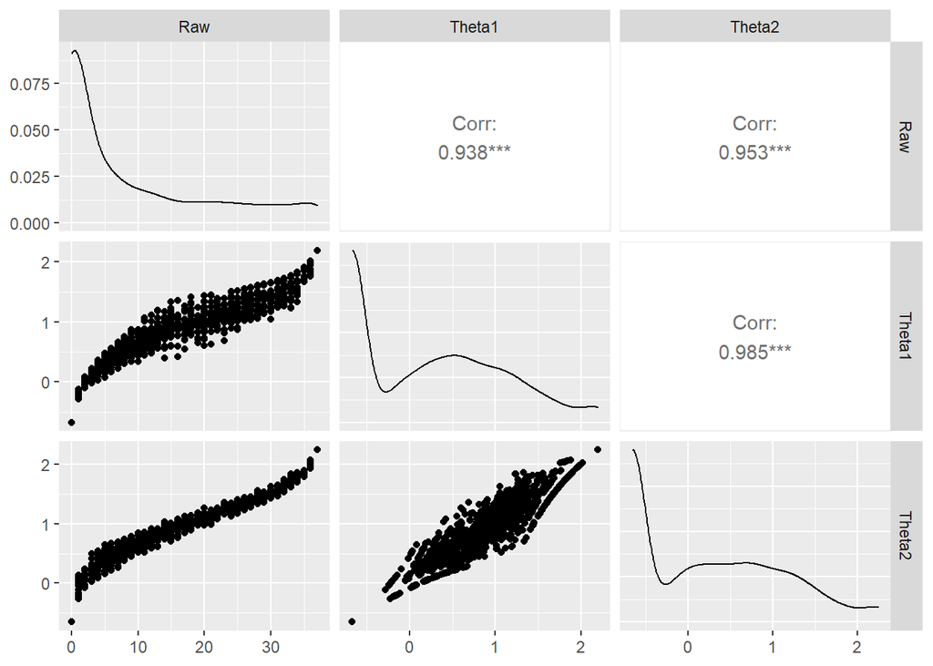

```r
Complex_short %>%
  mutate(
    Raw = rowSums(.[,1:37]),
    Theta1 = fscores(m3, method="MAP")[,1],
    Theta2 = fscores(m3, method="MAP")[,2]
  ) %>%
  dplyr::select(Raw, Theta1, Theta2) %>%
  ggpairs()
```

The correlation between the morphology latent variable and the syntax latent variable is like .99. They show the same results, more or less.

# 4 The Relationship between predictors and grammatical proficiency.

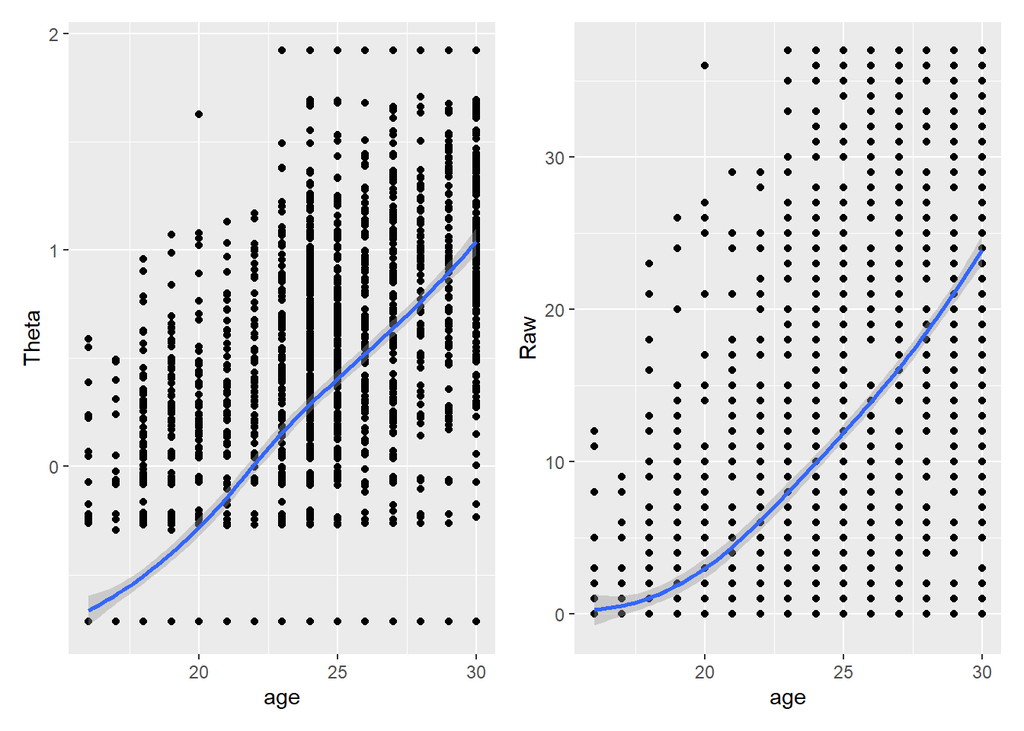

```r
by_Participant <-Complex_short_with_ids %>%
  mutate(
    Theta = fscores(m1, method="MAP")[,1],
    Raw = rowSums(.[2:38])
    ) %>%
  dplyr::select(data_id, Raw, Theta) %>%
  full_join(Complex) %>%
  group_by(data_id) %>%
  slice(1)
theta_by_age <- by_Participant %>%
  ggplot(aes(x=age, y=Theta)) + geom_point() + stat_smooth(method="loess")

raw_by_age <- by_Participant %>%
  ggplot(aes(x=age, y=Raw)) + geom_point() + stat_smooth(method="loess")

theta_by_age | raw_by_age
```

So, that’s really interesting. One I’ve accounted for the measurement error, the effect of age on grammatical complexity is pretty linear, whereas with the raw scores it’s clearly non-linear.

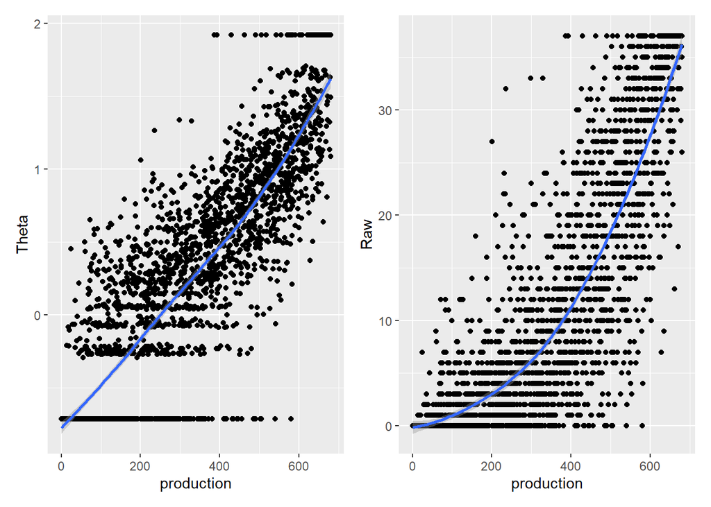

```r
theta_by_prod <- by_Participant %>%
  ggplot(aes(x=production, y=Theta)) + geom_point() + stat_smooth(method="loess")

raw_by_prod <- by_Participant %>%
  ggplot(aes(x=production, y=Raw)) + geom_point() + stat_smooth(method="loess")

theta_by_prod | raw_by_prod
```

```r
summary(lm(Theta ~ production, data=by_Participant))
```

```
##
## Call:
## lm(formula = Theta ~ production, data = by_Participant)
##
## Residuals:
##      Min       1Q   Median       3Q      Max
## -1.82923 -0.20034 -0.00348  0.20719  1.44997
##
## Coefficients:
##               Estimate Std. Error t value Pr(>|t|)
## (Intercept) -8.216e-01  1.203e-02  -68.31   <2e-16 ***
## production   3.336e-03  3.483e-05   95.81   <2e-16 ***
## ---
## Signif. codes:  0 '***' 0.001 '**' 0.01 '*' 0.05 '.' 0.1 ' ' 1
##
## Residual standard error: 0.3756 on 2786 degrees of freedom
## Multiple R-squared:  0.7671, Adjusted R-squared:  0.7671
## F-statistic:  9179 on 1 and 2786 DF,  p-value: < 2.2e-16
```

```r
Sys.Date()
```

```
## [1] "2021-06-29"
```

```r
R.Version()
```

```
## $platform
## [1] "x86_64-w64-mingw32"
##
## $arch
## [1] "x86_64"
##
## $os
## [1] "mingw32"
##
## $system
## [1] "x86_64, mingw32"
##
## $status
## [1] ""
##
## $major
## [1] "4"
##
## $minor
## [1] "0.2"
##
## $year
## [1] "2020"
##
## $month
## [1] "06"
##
## $day
## [1] "22"
##
## $`svn rev`
## [1] "78730"
##
## $language
## [1] "R"
##
## $version.string
## [1] "R version 4.0.2 (2020-06-22)"
##
## $nickname
## [1] "Taking Off Again"
```